# Desempenho dos alunos do 5º ano no Saeb 2023: análise descritiva

Eixo 4: Educação Básica Municipal (parceria SME Curitiba) · Projetos de Análise de Dados 2026/2

24/11/2026

# 1 Introdução

O Sistema de Avaliação da Educação Básica (Saeb), conduzido pelo Inep, avalia periodicamente o aprendizado dos estudantes brasileiros em Língua Portuguesa e Matemática. Além das provas, os alunos respondem a um questionário sobre seu perfil, sua família, sua rotina e sua percepção da escola, o que permite relacionar o desempenho a fatores de contexto.

Este trabalho, desenvolvido no âmbito do Eixo 4: Educação Básica Municipal, em parceria com a Secretaria Municipal de Educação de Curitiba (SME), utiliza os microdados do Saeb 2023 para os alunos do 5º ano do Ensino Fundamental. O foco está nos alunos com desempenho abaixo do nível básico, isto é, que não atingiram o mínimo de aprendizado esperado para a etapa.

A hipótese do trabalho é que características do aluno, da família, da rotina e da relação com a escola estão associadas a estar abaixo do nível básico. A análise busca responder qual a proporção de alunos do 5º ano abaixo do nível básico em Língua Portuguesa e em Matemática, quais características estão associadas a isso e como Curitiba se compara ao Brasil.

Este relatório traz a etapa descritiva, com cada característica analisada separadamente. Os resultados servirão de base para a etapa de modelagem por regressão logística.

# 2 Dados e metodologia

## 2.1 Fonte dos dados

Foram utilizados os microdados do Saeb 2023 disponibilizados pelo Inep, arquivo `TS_ALUNO_5EF`, com uma linha por aluno do 5º ano: 2.442.143 alunos e 152 variáveis, entre identificação, controle da aplicação, proficiências e as respostas ao questionário do aluno.

## 2.2 Amostra Brasil

Pelo tamanho da base, foi sorteada uma amostra estratificada por Unidade da Federação, com alocação proporcional ao número de alunos de cada UF, totalizando 32.000 alunos. A proporção usada é a de alunos por UF na própria base, e não a proporção populacional de cada estado. O tamanho de 32.000 foi escolhido para que restassem cerca de 10 mil alunos depois dos filtros de qualidade. Foi usada semente fixa (`set.seed(123)`) para garantir a reprodutibilidade da amostra.

## 2.3 Filtros de qualidade

Foram mantidos apenas os alunos que tinham situação consistente com o Censo Escolar, que estiveram presentes e preencheram as provas de Língua Portuguesa e Matemática, que tiveram proficiência calculada nas duas disciplinas e que preencheram o questionário do aluno respondendo a todas as suas 70 questões, sem respostas em branco ou inválidas. Após os filtros, a amostra Brasil ficou com 10.068 alunos.

A tabela abaixo mostra quantos alunos cada filtro remove quando aplicado à base completa do Inep.

| Etapa | Alunos | Removidos | % restante |
| --- | --- | --- | --- |
| Base original | 2.442.143 |  | 100,0% |
| Situação consistente no Censo | 2.433.404 | 8.739 | 99,6% |
| Presente nas provas de LP e MT | 2.096.324 | 337.080 | 85,8% |
| Preencheu as provas de LP e MT | 2.081.291 | 15.033 | 85,2% |
| Tem proficiência em LP e MT | 2.081.287 | 4 | 85,2% |
| Preencheu o questionário | 2.063.719 | 17.568 | 84,5% |
| Respondeu todas as 70 questões | 761.673 | 1.302.046 | 31,2% |

A exigência de questionário completo é o filtro que mais remove alunos. Os alunos excluídos por ela têm desempenho inferior e uma proporção bem maior abaixo do nível básico, como mostra a tabela seguinte. Assim, as proporções deste relatório subestimam a parcela real de alunos abaixo do básico. O filtro foi mantido, com a mesma regra para Brasil e Curitiba, para que os dois sejam comparáveis.

| Grupo | Alunos | Média LP | Média MT | Abaixo do básico LP | Abaixo do básico MT |
| --- | --- | --- | --- | --- | --- |
| Brasil: questionário completo | 761.673 | 224 | 236 | 7,9% | 11,3% |
| Brasil: alguma questão em branco | 1.302.046 | 200 | 210 | 19,5% | 27,0% |
| Curitiba: questionário completo | 4.452 | 233 | 246 | 4,2% | 6,8% |
| Curitiba: todos com nota válida | 13.973 | 219 | 231 | 9,0% | 12,8% |

## 2.4 Variáveis resposta

A proficiência do Saeb foi convertida em duas variáveis dicotômicas, a partir dos cortes de nível de aprendizado propostos pelo professor para o 5º ano:

| Nível de aprendizado | Língua Portuguesa | Matemática |
| --- | --- | --- |
| Abaixo do básico | até 150 | até 175 |
| Básico | mais de 150 a 200 | mais de 175 a 200 |
| Adequado | mais de 200 a 250 | mais de 200 a 225 |
| Avançado | mais de 250 | mais de 225 |

A variável `abaixo_LP` vale 1 se a proficiência em Língua Portuguesa for menor ou igual a 150, e 0 caso contrário. A variável `abaixo_MT` vale 1 se a proficiência em Matemática for menor ou igual a 175, e 0 caso contrário.

## 2.5 Bases de treino, teste e Curitiba

Pensando na etapa de modelagem, a amostra Brasil foi dividida em treino (90%, 9.062 alunos) e teste (10%, 1.006 alunos), com sorteio estratificado pelas duas variáveis resposta. Todas as análises deste relatório usam apenas a base de treino. A base de teste fica reservada para a avaliação final do modelo.

Como a amostra Brasil contém poucos alunos de Curitiba, foi construída uma base separada com todos os alunos da cidade (UF = Paraná e área = capital), aplicando os mesmos filtros: 4.452 alunos em 190 escolas. Dessas escolas, 95,8% são públicas, e elas concentram 98,6% dos alunos da base. A base não permite distinguir escolas municipais de estaduais.

## 2.6 Variáveis analisadas e intervalos de confiança

O questionário do aluno tem 70 questões. Este relatório apresenta as características que mostraram associação consistente com estar abaixo do nível básico e que têm relação com a hipótese.

Como uma proporção calculada sobre poucos alunos é pouco confiável, os gráficos mostram o número de alunos de cada categoria, indicado por “n”, e as tabelas trazem o intervalo de confiança de 95% de cada proporção, calculado pelo método de Wilson. Quanto menor o grupo, mais largo o intervalo.

Quando os intervalos de duas categorias não se sobrepõem, a diferença entre elas dificilmente se deve ao acaso. Quando se sobrepõem, não afirmamos que há diferença. A média geral da base de treino é de 7,7% de alunos abaixo do básico em Língua Portuguesa (LP) e 11,0% em Matemática (MT).

Toda a análise foi feita em R (pacotes `tidyverse` e `scales`), com o código versionado no GitHub e reprodutível a partir dos microdados do Inep.

# 3 Quantos alunos estão abaixo do básico

Na amostra Brasil, 7,7% dos alunos estão abaixo do nível básico em Língua Portuguesa e 11,0% em Matemática, ambos acima da expectativa de 5%.

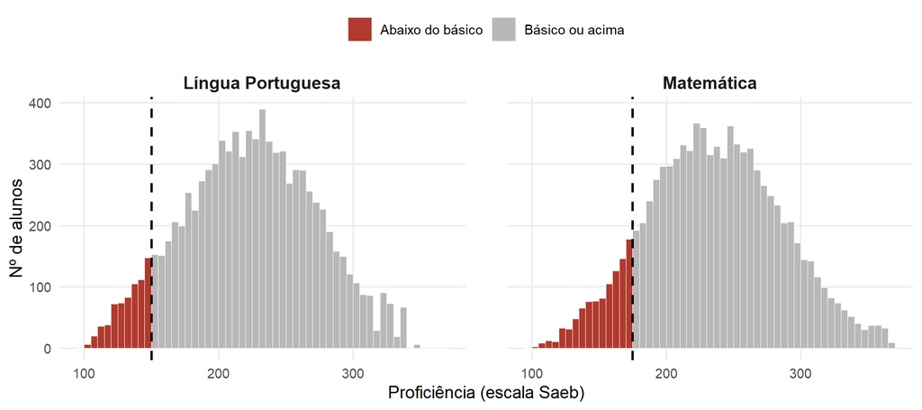

As duas distribuições são aproximadamente simétricas, com médias de 223 pontos em LP e 236 em MT. Os alunos abaixo do básico aparecem em vermelho. O corte de Matemática (175) fica mais próximo do centro da distribuição do que o de Língua Portuguesa (150), o que explica a proporção maior em Matemática.

| Situação | Alunos | % dos alunos |
| --- | --- | --- |
| Abaixo nas duas | 378 | 4,2% |
| Abaixo só em LP | 316 | 3,5% |
| Abaixo só em MT | 622 | 6,9% |
| Básico ou acima nas duas | 7.746 | 85,5% |

O indicador combinado mostra que 85,5% dos alunos atingem o nível básico nas duas disciplinas e 4,2% estão abaixo nas duas. Entre os que estão abaixo em apenas uma, predomina Matemática (6,9%, contra 3,5% só em LP). Matemática é o principal ponto de atenção.

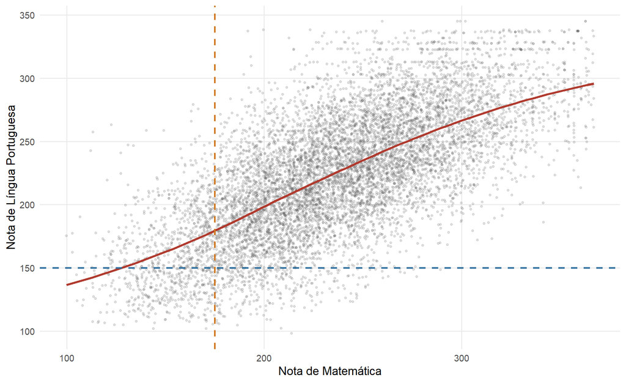

As notas das duas disciplinas são fortemente correlacionadas (r = 0,69), e os alunos com dificuldade tendem a tê-la nas duas áreas. As linhas tracejadas dividem os alunos nos quatro grupos da tabela acima. A curva vermelha é uma suavização loess (regressão local), que mostra a tendência entre as duas notas sem supor uma reta. Ela é crescente e praticamente linear na faixa central das notas. É de se esperar que os fatores associados ao baixo desempenho sejam em boa parte os mesmos para LP e MT, o que aparece nas seções seguintes.

O sexo é a única característica em que as disciplinas se comportam de modo diferente. As meninas têm menos alunas abaixo do básico em LP (6,0% contra 8,8% dos meninos), e em MT a situação se inverte levemente (11,4% contra 9,8%).

# 4 Quais grupos concentram mais alunos abaixo do básico

Foram formados 18 grupos de alunos, em 6 blocos, e cada grupo foi comparado com os demais alunos da base. No gráfico, o ponto vermelho é a proporção de alunos abaixo do básico no grupo, com a faixa clara indicando o intervalo de confiança de 95%, e o ponto cinza é a proporção entre os demais alunos.

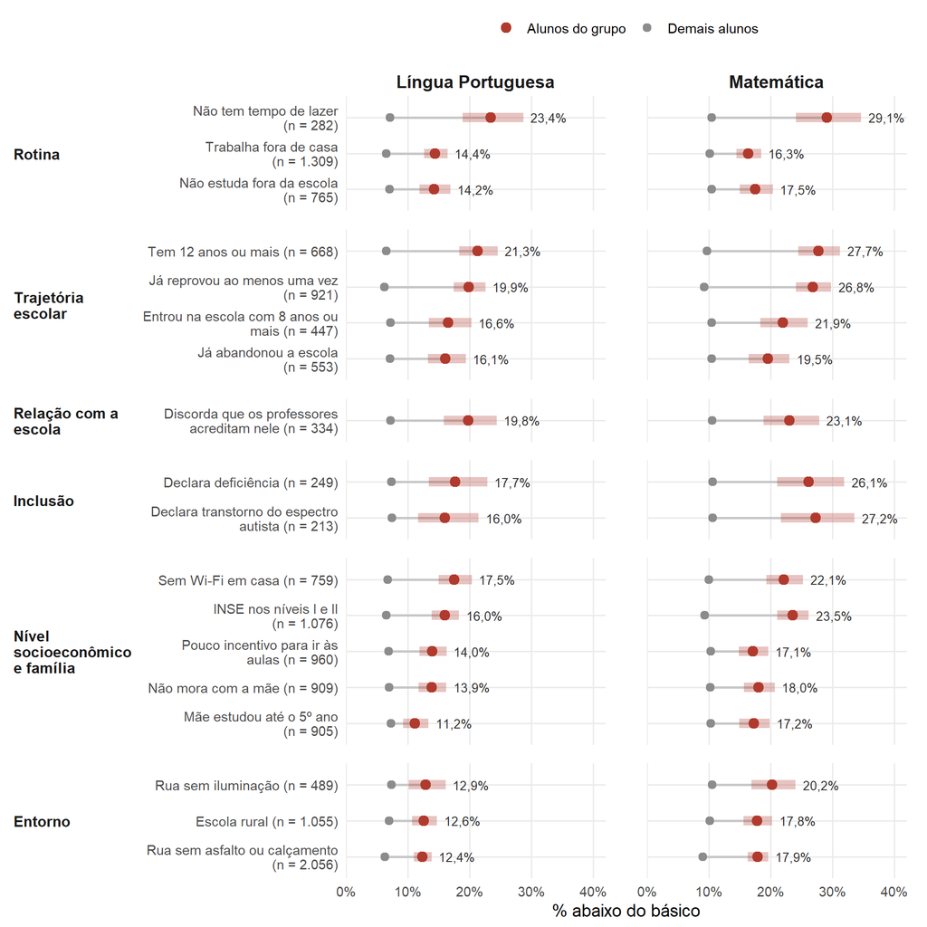

Em todos os grupos a proporção de alunos abaixo do básico é maior que a dos demais, e em nenhum deles o intervalo de confiança alcança o ponto cinza. A proporção do grupo vai de uma vez e meia a pouco mais de três vezes a dos demais, com o mesmo padrão nas duas disciplinas.

As proporções mais altas estão entre os alunos que não têm tempo de lazer (23,4% em LP), os que têm 12 anos ou mais (21,3%), os que já reprovaram (19,9%) e os que discordam que os professores acreditam neles (19,8%). Os grupos de entorno e de nível socioeconômico vêm depois, com proporções entre 11% e 18% em LP.

O tamanho dos grupos também varia bastante. Os alunos sem tempo de lazer são o grupo de maior proporção, mas são só 282. Já os que moram em rua sem asfalto têm proporção menor (12,4% em LP) e são 2.056. Para a SME as duas informações são úteis, porque uma indica onde o risco é mais alto e a outra onde há mais alunos.

As tabelas abaixo trazem os mesmos números por bloco, com os intervalos de confiança. A média geral da base é de 7,7% em LP e 11,0% em MT.

**Rotina**

| Grupo | Alunos | % dos alunos | % abaixo do básico LP (IC 95%) | % abaixo do básico MT (IC 95%) |
| --- | --- | --- | --- | --- |
| Não tem tempo de lazer | 282 | 3,1 | 23,4 (18,8 a 28,7) | 29,1 (24,1 a 34,6) |
| Trabalha fora de casa | 1.309 | 14,4 | 14,4 (12,6 a 16,4) | 16,3 (14,4 a 18,4) |
| Não estuda fora da escola | 765 | 8,4 | 14,2 (11,9 a 16,9) | 17,5 (15,0 a 20,4) |

**Trajetória escolar**

| Grupo | Alunos | % dos alunos | % abaixo do básico LP (IC 95%) | % abaixo do básico MT (IC 95%) |
| --- | --- | --- | --- | --- |
| Tem 12 anos ou mais | 668 | 7,4 | 21,3 (18,3 a 24,5) | 27,7 (24,4 a 31,2) |
| Já reprovou ao menos uma vez | 921 | 10,2 | 19,9 (17,4 a 22,6) | 26,8 (24,1 a 29,8) |
| Entrou na escola com 8 anos ou mais | 447 | 4,9 | 16,6 (13,4 a 20,3) | 21,9 (18,3 a 26,0) |
| Já abandonou a escola | 553 | 6,1 | 16,1 (13,3 a 19,4) | 19,5 (16,4 a 23,0) |

**Relação com a escola**

| Grupo | Alunos | % dos alunos | % abaixo do básico LP (IC 95%) | % abaixo do básico MT (IC 95%) |
| --- | --- | --- | --- | --- |
| Discorda que os professores acreditam nele | 334 | 3,7 | 19,8 (15,8 a 24,4) | 23,1 (18,9 a 27,9) |

**Inclusão**

| Grupo | Alunos | % dos alunos | % abaixo do básico LP (IC 95%) | % abaixo do básico MT (IC 95%) |
| --- | --- | --- | --- | --- |
| Declara deficiência | 249 | 2,7 | 17,7 (13,4 a 22,9) | 26,1 (21,0 a 31,9) |
| Declara transtorno do espectro autista | 213 | 2,4 | 16,0 (11,7 a 21,5) | 27,2 (21,7 a 33,6) |

**Nível socioeconômico e família**

| Grupo | Alunos | % dos alunos | % abaixo do básico LP (IC 95%) | % abaixo do básico MT (IC 95%) |
| --- | --- | --- | --- | --- |
| Sem Wi-Fi em casa | 759 | 8,4 | 17,5 (15,0 a 20,4) | 22,1 (19,3 a 25,2) |
| INSE nos níveis I e II | 1.076 | 11,9 | 16,0 (13,9 a 18,3) | 23,5 (21,1 a 26,1) |
| Pouco incentivo para ir às aulas | 960 | 10,6 | 14,0 (11,9 a 16,3) | 17,1 (14,8 a 19,6) |
| Não mora com a mãe | 909 | 10,0 | 13,9 (11,8 a 16,3) | 18,0 (15,7 a 20,7) |
| Mãe estudou até o 5º ano | 905 | 10,0 | 11,2 (9,3 a 13,4) | 17,2 (14,9 a 19,8) |

**Entorno**

| Grupo | Alunos | % dos alunos | % abaixo do básico LP (IC 95%) | % abaixo do básico MT (IC 95%) |
| --- | --- | --- | --- | --- |
| Rua sem iluminação | 489 | 5,4 | 12,9 (10,2 a 16,1) | 20,2 (16,9 a 24,0) |
| Escola rural | 1.055 | 11,6 | 12,6 (10,7 a 14,7) | 17,8 (15,6 a 20,2) |
| Rua sem asfalto ou calçamento | 2.056 | 22,7 | 12,4 (11,0 a 13,8) | 17,9 (16,3 a 19,6) |

# 5 Resultados por bloco

## 5.1 Trajetória escolar

Reprovação, idade, abandono e idade de entrada na escola estão ligados à mesma situação, a do aluno atrasado em relação à série.

### 5.1.1 Reprovação

| Categoria | Alunos | % dos alunos | % abaixo do básico LP (IC 95%) | % abaixo do básico MT (IC 95%) |
| --- | --- | --- | --- | --- |
| Não | 8.141 | 89,8 | 6,3 (5,8 a 6,8) | 9,2 (8,6 a 9,9) |
| Sim, uma vez | 721 | 8,0 | 20,9 (18,1 a 24,1) | 25,1 (22,1 a 28,4) |
| Sim, duas vezes ou mais | 200 | 2,2 | 16,0 (11,6 a 21,7) | 33,0 (26,9 a 39,8) |

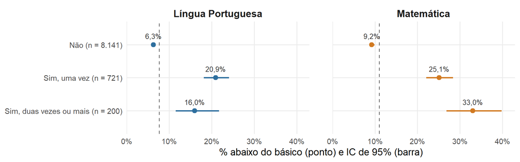

A reprovação é a variável mais fortemente associada ao baixo desempenho. Entre os alunos que já reprovaram uma vez, 20,9% estão abaixo do básico em LP, mais de três vezes a proporção dos que nunca reprovaram (6,3%). Em MT, a proporção cresce com o número de reprovações (9,2%, 25,1% e 33,0%). Em LP, os que reprovaram duas vezes ou mais aparecem com proporção menor que os que reprovaram uma vez, mas os intervalos se sobrepõem e o grupo tem só 200 alunos, então essa diferença não é confiável.

Os alunos que já repetiram de ano continuam muito mais concentrados abaixo do nível básico. Não é possível dizer, com esses dados, o que teria acontecido com eles sem a reprovação, mas para a SME ela serve como sinal de alerta para identificar quem precisa de acompanhamento.

### 5.1.2 Idade

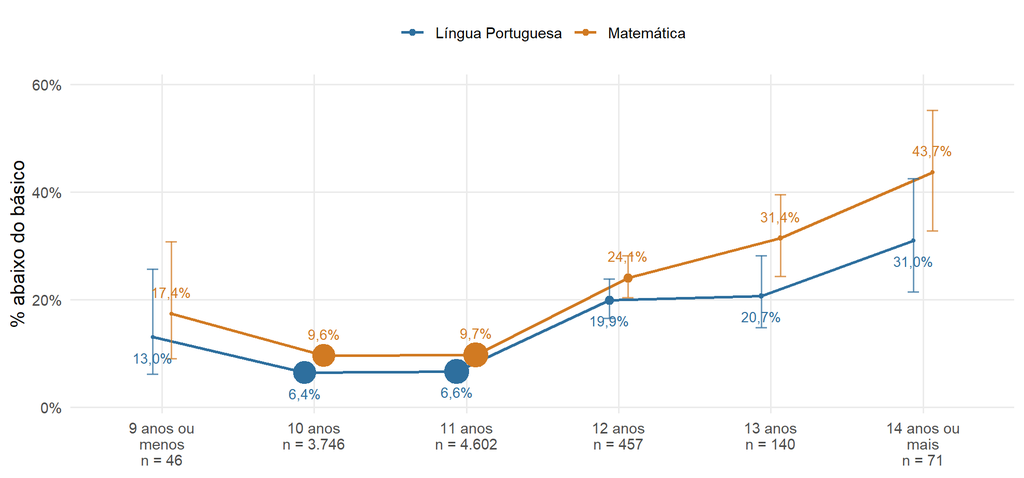

Quase todos os alunos têm 10 ou 11 anos, idade esperada para o 5º ano, e nesse grupo cerca de 6,5% estão abaixo do básico em LP. A partir dos 12 anos a proporção triplica (19,9% aos 12 anos) e chega a 31,0% entre os de 14 anos ou mais. Esses grupos têm poucos alunos, como mostram os pontos menores e as barras de erro mais largas, mas a tendência é a mesma nos três. O padrão reflete a distorção idade-série, já que alunos mais velhos que o esperado em geral reprovaram ou interromperam os estudos. O grupo de 9 anos ou menos tem apenas 46 alunos e não permite conclusão.

Agrupando as idades, os grupos ficam maiores:

| Categoria | Alunos | % dos alunos | % abaixo do básico LP (IC 95%) | % abaixo do básico MT (IC 95%) |
| --- | --- | --- | --- | --- |
| 9 anos ou menos | 46 | 0,5 | 13,0 (6,1 a 25,7) | 17,4 (9,1 a 30,7) |
| 10 e 11 anos | 8.348 | 92,1 | 6,5 (6,0 a 7,1) | 9,7 (9,1 a 10,3) |
| 12 anos ou mais | 668 | 7,4 | 21,3 (18,3 a 24,5) | 27,7 (24,4 a 31,2) |

### 5.1.3 Abandono escolar e idade de entrada na escola

| Categoria | Alunos | % dos alunos | % abaixo do básico LP (IC 95%) | % abaixo do básico MT (IC 95%) |
| --- | --- | --- | --- | --- |
| Abandonou a escola: nunca | 8.509 | 93,9 | 7,1 (6,6 a 7,7) | 10,5 (9,8 a 11,2) |
| Abandonou a escola: sim, uma vez | 427 | 4,7 | 14,8 (11,7 a 18,4) | 17,6 (14,2 a 21,5) |
| Abandonou a escola: sim, duas vezes ou mais | 126 | 1,4 | 20,6 (14,5 a 28,5) | 26,2 (19,3 a 34,5) |
| Entrou na escola com 3 anos ou menos | 3.891 | 42,9 | 7,2 (6,4 a 8,1) | 9,5 (8,7 a 10,5) |
| Entrou na escola com 4 ou 5 anos | 3.333 | 36,8 | 6,9 (6,1 a 7,8) | 10,7 (9,7 a 11,8) |
| Entrou na escola com 6 ou 7 anos | 1.391 | 15,3 | 7,8 (6,5 a 9,3) | 12,4 (10,8 a 14,3) |
| Entrou na escola com 8 anos ou mais | 447 | 4,9 | 16,6 (13,4 a 20,3) | 21,9 (18,3 a 26,0) |

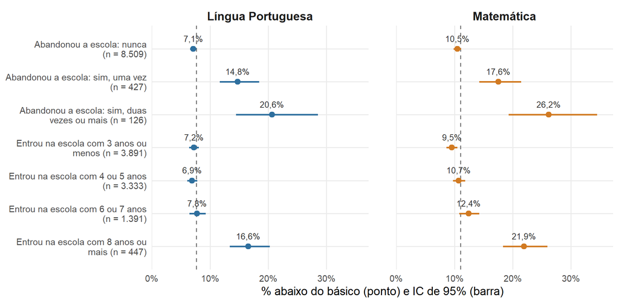

O abandono segue o mesmo padrão da reprovação. A proporção abaixo do básico em LP dobra entre quem abandonou a escola uma vez (14,8%, contra 7,1% de quem nunca abandonou) e chega perto do triplo entre quem abandonou duas vezes ou mais (20,6%), grupo que tem apenas 126 alunos.

Na idade de entrada na escola, não há diferença entre os que entraram com até 7 anos, que ficam próximos da média geral. Só os que entraram com 8 anos ou mais se destacam (16,6%), o que também é uma situação de distorção idade-série.

## 5.2 Nível socioeconômico e família

### 5.2.1 Nível socioeconômico (INSE)

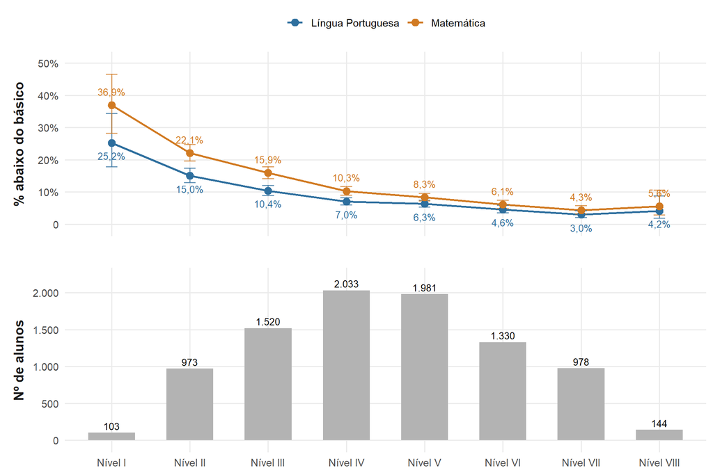

É o fator com o gradiente mais nítido da análise. A proporção em LP cai de 25,2% no nível I para 3,0% no nível VII, e em MT de 36,9% para 4,3%. O painel de baixo mostra o número de alunos em cada nível. Os níveis I e VIII têm poucos alunos (103 e 144) e barras de erro largas, então a pequena subida no nível VIII não indica diferença em relação ao VII. Entre os níveis II e VII, onde está a maioria dos alunos, a queda é consistente.

Muitas das variáveis deste bloco e do próximo, como bens, escolaridade dos pais e infraestrutura da rua, entram no cálculo do INSE ou andam junto com ele. Por isso elas em boa parte repetem o mesmo resultado.

### 5.2.2 Escolaridade da mãe

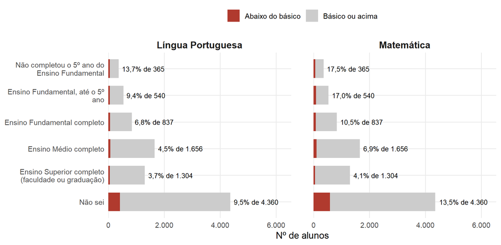

No gráfico, o comprimento da barra é o número de alunos da categoria e a parte vermelha são os alunos abaixo do básico. Chama atenção o tamanho do grupo “Não sei”: 48,1% dos alunos não sabem a escolaridade da mãe.

Entre os que sabem, quanto maior a escolaridade da mãe, menor a proporção de alunos abaixo do básico, de 13,7% (mãe que não completou o 5º ano) a 3,7% (mãe com ensino superior) em LP. Esse gradiente vale só para metade da base. O grupo “Não sei” tem proporção acima da média (9,5% em LP), então não parece ser apenas falta de informação. Na modelagem, o “Não sei” deve entrar como uma categoria da variável.

| Categoria | Alunos | % dos alunos | % abaixo do básico LP (IC 95%) | % abaixo do básico MT (IC 95%) |
| --- | --- | --- | --- | --- |
| Não completou o 5º ano do Ensino Fundamental | 365 | 4,0 | 13,7 (10,5 a 17,6) | 17,5 (14,0 a 21,8) |
| Ensino Fundamental, até o 5º ano | 540 | 6,0 | 9,4 (7,3 a 12,2) | 17,0 (14,1 a 20,4) |
| Ensino Fundamental completo | 837 | 9,2 | 6,8 (5,3 a 8,7) | 10,5 (8,6 a 12,8) |
| Ensino Médio completo | 1.656 | 18,3 | 4,5 (3,6 a 5,6) | 6,9 (5,8 a 8,3) |
| Ensino Superior completo (faculdade ou graduação) | 1.304 | 14,4 | 3,7 (2,8 a 4,8) | 4,1 (3,2 a 5,4) |
| Não sei | 4.360 | 48,1 | 9,5 (8,7 a 10,4) | 13,5 (12,5 a 14,5) |

Os intervalos das mães com ensino médio ou superior não se sobrepõem aos das mães que estudaram até o 5º ano.

### 5.2.3 Composição da casa e acesso digital

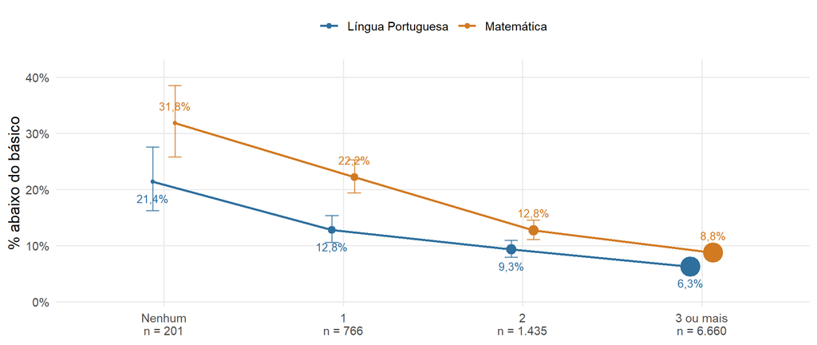

A quantidade de celulares com internet em casa mostra um gradiente claro: 21,4% dos alunos sem nenhum celular estão abaixo do básico em LP, contra 6,3% dos que têm três ou mais. A grande maioria dos alunos está na última categoria. Com a rede Wi-Fi ocorre o mesmo: entre os 8,4% de alunos sem Wi-Fi em casa, 17,5% estão abaixo do básico em LP, contra 6,8% dos demais. Como essas variáveis também são componentes do INSE, o resultado reflete principalmente o nível socioeconômico.

Quanto à composição da casa, 10,0% dos alunos não moram com a mãe, madrasta ou mulher responsável, e entre eles a proporção abaixo do básico em LP é o dobro da dos demais (13,9% contra 7,0%). Sobre o incentivo dos responsáveis, 89,4% dos alunos dizem que sempre ou quase sempre são incentivados a ir às aulas, e entre os demais a proporção abaixo do básico em LP também é o dobro (14,0% contra 6,9%).

## 5.3 Vulnerabilidade do entorno

As variáveis de infraestrutura da rua e de localização da escola descrevem o lugar onde o aluno vive e se sobrepõem entre si e com o INSE.

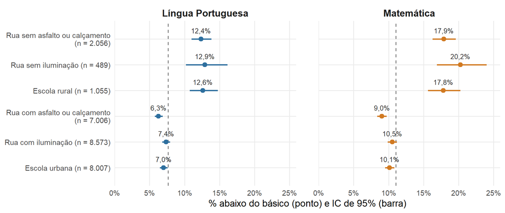

As três situações de vulnerabilidade ficam acima da média geral e as situações opostas ficam abaixo, sem sobreposição entre os intervalos. Os alunos que moram em ruas sem asfalto têm o dobro da proporção abaixo do básico em LP (12,4% contra 6,3%). Nas ruas sem iluminação (12,9% contra 7,4%) e nas escolas rurais (12,6% contra 7,0%), a proporção é cerca de 1,7 a 1,8 vez maior. A falta de asfalto é a situação mais comum (2.056 alunos). Para Curitiba, a localização da escola não ajuda, pois todos os alunos da base da cidade estão em escolas urbanas.

## 5.4 Rotina

As três perguntas sobre o uso do tempo fora da escola, em dias de aula, têm as mesmas opções de resposta e foram colocadas no mesmo gráfico. O tamanho do ponto indica o número de alunos.

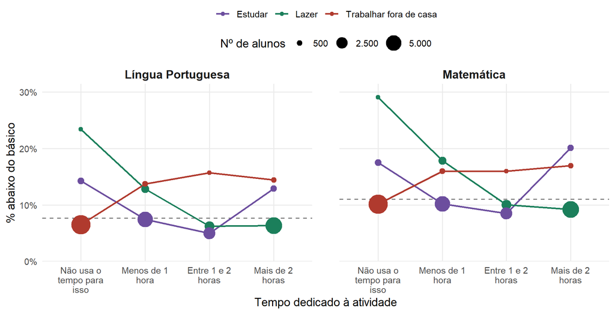

No lazer, a proporção diminui conforme o tempo aumenta. Os alunos que não têm nenhum tempo de lazer têm 23,4% abaixo do básico em LP, contra 6,4% dos que têm mais de 2 horas. É pouco provável que o lazer em si melhore o desempenho. A falta de lazer deve indicar uma rotina sobrecarregada, com trabalho ou cuidado com a casa e com irmãos, que é uma situação de vulnerabilidade. Esse grupo tem 282 alunos, mas a proporção continua alta na categoria seguinte, que tem mais de mil.

O tempo de estudo tem forma de “U”. Os alunos que não estudam fora da escola (14,2% em LP) e os que estudam mais de 2 horas (12,9%) têm as maiores proporções abaixo do básico, e os que estudam de 1 a 2 horas, a menor (5,0%). Uma interpretação possível é que os alunos com mais dificuldade precisam estudar mais, de modo que o tempo de estudo seria consequência da dificuldade. Na modelagem, essa variável deve entrar como categórica.

No trabalho fora de casa, 14,4% dos alunos do 5º ano declaram usar parte do tempo para trabalhar, um número alto para crianças de cerca de 10 anos. Entre eles, a proporção abaixo do básico em LP é o dobro da dos demais (14,4% contra 6,5%), e praticamente não muda com a quantidade de horas. O resultado interessa à SME por envolver trabalho infantil, embora a resposta dependa de como a criança entende “trabalhar fora de casa”.

| Categoria | Alunos | % dos alunos | % abaixo do básico LP (IC 95%) | % abaixo do básico MT (IC 95%) |
| --- | --- | --- | --- | --- |
| Lazer: não usa o tempo para isso | 282 | 3,1 | 23,4 (18,8 a 28,7) | 29,1 (24,1 a 34,6) |
| Lazer: menos de 1 hora | 1.105 | 12,2 | 12,9 (11,0 a 15,0) | 17,8 (15,7 a 20,2) |
| Lazer: entre 1 e 2 horas | 1.821 | 20,1 | 6,3 (5,2 a 7,5) | 10,0 (8,8 a 11,5) |
| Lazer: mais de 2 horas | 5.854 | 64,6 | 6,4 (5,8 a 7,0) | 9,2 (8,5 a 10,0) |
| Estudar: não usa o tempo para isso | 765 | 8,4 | 14,2 (11,9 a 16,9) | 17,5 (15,0 a 20,4) |
| Estudar: menos de 1 hora | 4.806 | 53,0 | 7,4 (6,7 a 8,2) | 10,2 (9,4 a 11,1) |
| Estudar: entre 1 e 2 horas | 2.800 | 30,9 | 5,0 (4,2 a 5,8) | 8,5 (7,5 a 9,6) |
| Estudar: mais de 2 horas | 691 | 7,6 | 12,9 (10,6 a 15,6) | 20,1 (17,3 a 23,3) |
| Trabalhar fora de casa: não usa o tempo para isso | 7.753 | 85,6 | 6,5 (6,0 a 7,1) | 10,1 (9,5 a 10,8) |
| Trabalhar fora de casa: menos de 1 hora | 525 | 5,8 | 13,7 (11,0 a 16,9) | 16,0 (13,1 a 19,4) |
| Trabalhar fora de casa: entre 1 e 2 horas | 319 | 3,5 | 15,7 (12,1 a 20,1) | 16,0 (12,4 a 20,4) |
| Trabalhar fora de casa: mais de 2 horas | 465 | 5,1 | 14,4 (11,5 a 17,9) | 17,0 (13,8 a 20,7) |

Os intervalos de quem não tem lazer, de quem não estuda e de quem trabalha fora não se sobrepõem aos das categorias de menor proporção da mesma atividade.

## 5.5 Relação com a escola

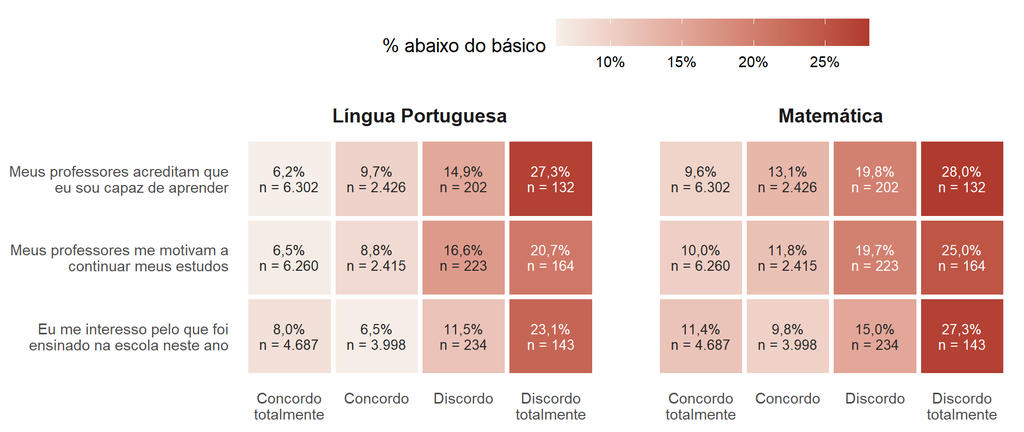

O mapa de calor reúne três afirmações com as mesmas opções de resposta. Cada célula traz a proporção de alunos abaixo do básico e o número de alunos que deram aquela resposta. Quanto mais o aluno discorda, maior a proporção abaixo do básico. Ao mesmo tempo, poucos alunos discordam: a grande maioria concorda com as afirmações, e menos de 2% discordam totalmente de cada uma.

O item mais forte é “meus professores acreditam que eu sou capaz de aprender”, em que a proporção em LP sobe de 6,2% (concordo totalmente) para 27,3% (discordo totalmente). No item de interesse pelo conteúdo, só os que discordam se diferenciam.

Não dá para saber a direção dessa relação. O aluno pode ir mal por não se sentir apoiado, ou pode sentir que os professores não acreditam nele porque vai mal. De qualquer forma, o resultado mostra a importância da relação entre professor e aluno e indica um grupo pequeno, mas de risco alto, que pode ser identificado pela forma como percebe a escola.

## 5.6 Inclusão: deficiência e transtorno do espectro autista

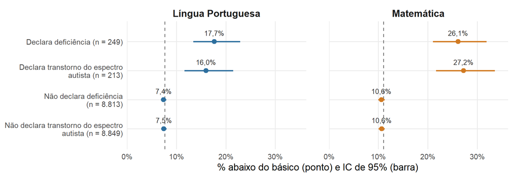

Os alunos que declaram ter deficiência ou transtorno do espectro autista têm mais que o dobro da proporção abaixo do básico em LP (17,7% e 16,0%) e em MT (26,1% e 27,2%). São grupos pequenos (249 e 213 alunos), mas os intervalos não se sobrepõem aos dos demais alunos.

O resultado é relevante para as políticas de educação inclusiva da SME. É preciso considerar que a condição é declarada pelo próprio aluno e que os alunos com maior dificuldade são os que mais ficam de fora da base por não completarem o questionário.

# 6 Força das associações

Para comparar a força da associação de cada variável com estar abaixo do nível básico, foi usado o V de Cramér, calculado a partir do teste qui-quadrado de independência. Ele varia de 0 (nenhuma associação) a 1 (associação perfeita). Como referência usual, valores próximos de 0,1 indicam associação fraca e próximos de 0,3, moderada.

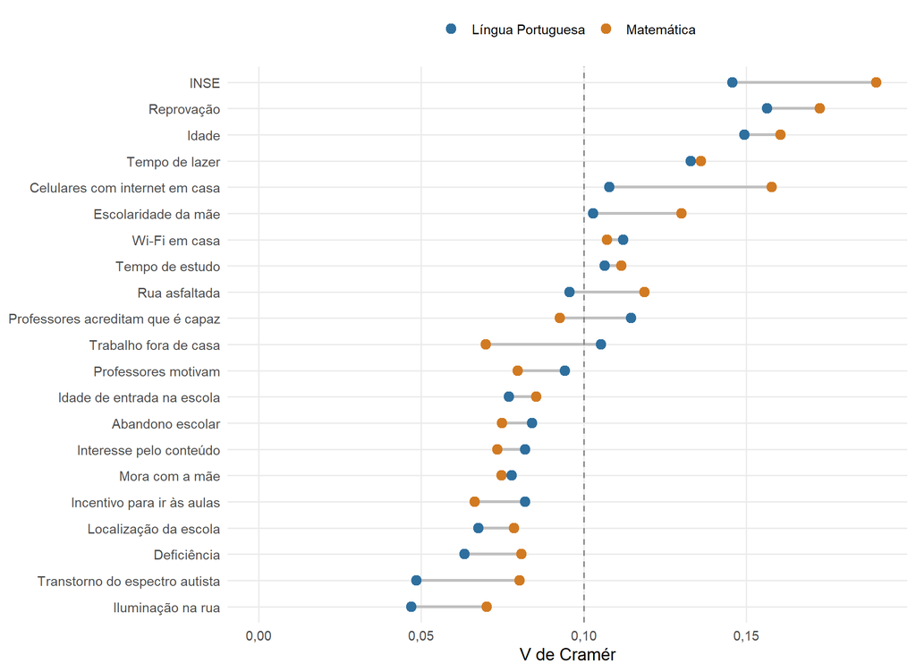

Todas as variáveis apresentam associação estatisticamente significativa (p < 0,001), mas de intensidade fraca (V entre 0,05 e 0,19), o que é esperado quando o evento estudado é pouco frequente. As associações mais fortes são as do INSE, da reprovação (V de 0,156 em LP e 0,173 em MT) e da idade, seguidas do tempo de lazer, dos celulares em casa e da escolaridade da mãe. Na maior parte das variáveis os valores de LP e MT são próximos. O INSE e os celulares são mais associados a Matemática, e o trabalho fora de casa, a Língua Portuguesa.

O V de Cramér mede o quanto a variável separa o conjunto dos alunos, o que é diferente do risco de um grupo específico. Deficiência e transtorno do espectro autista têm V baixo (0,063 e 0,048 em LP) mesmo com o dobro da proporção de alunos abaixo do básico, porque atingem menos de 3% dos alunos. Assim, um V baixo não quer dizer que o grupo não mereça atenção.

Como essas medidas olham cada variável isoladamente, parte delas pode refletir o efeito de outras, em especial do nível socioeconômico. A separação desses efeitos será feita na etapa de modelagem.

# 7 Curitiba × Brasil

## 7.1 Visão geral

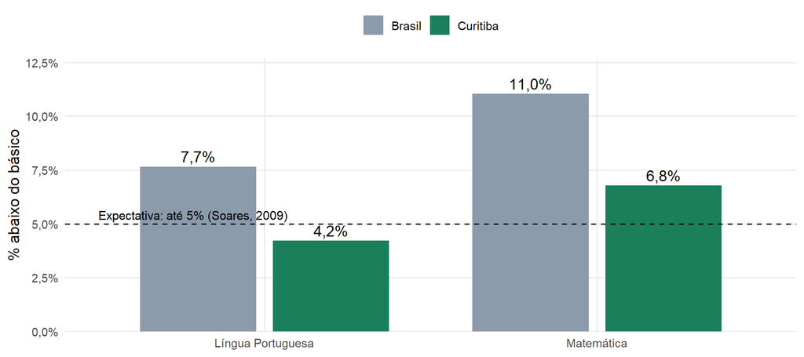

A proporção de alunos abaixo do nível básico em Curitiba é menor que a do Brasil nas duas disciplinas: 4,2% em LP, abaixo da linha de expectativa de 5%, e 6,8% em MT, ainda acima dela. Como no Brasil, Matemática é o ponto mais frágil. Em média, os 4.452 alunos de Curitiba têm notas cerca de 10 pontos mais altas que os do Brasil nas duas disciplinas (233 contra 223 em LP e 246 contra 236 em MT).

Nos gráficos seguintes, categorias com menos de 30 alunos não têm a proporção calculada.

## 7.2 Reprovação

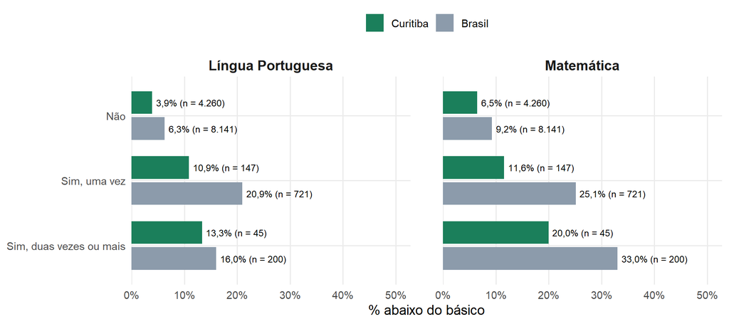

A reprovação é fortemente associada a estar abaixo do básico nos dois grupos. Entre os alunos que reprovaram uma vez, porém, a proporção abaixo do básico em Curitiba é cerca da metade da do Brasil (10,9% contra 20,9% em LP). Isso pode indicar que a rede da cidade consegue recuperar melhor o aluno reprovado, mas também pode refletir o perfil socioeconômico mais alto dos alunos de Curitiba. De todo modo, o aluno reprovado continua em situação pior que a dos que nunca reprovaram (3,9% em Curitiba). Os reprovados são poucos na cidade (147 e 45 alunos), então essa comparação deve ser vista com cautela.

## 7.3 Escolaridade da mãe

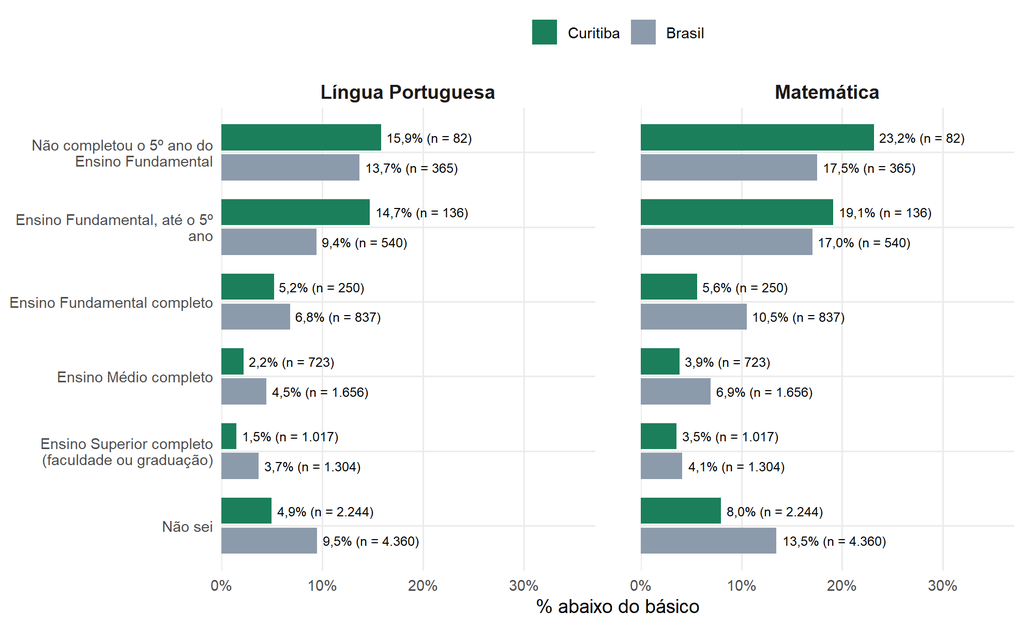

Nas categorias de maior escolaridade e no “Não sei”, Curitiba tem proporção menor que o Brasil. Entre os filhos de mães com até o 5º ano do fundamental isso não acontece, e as proporções de Curitiba são iguais ou maiores (por exemplo, 23,2% contra 17,5% em MT entre os filhos de mães que não completaram o 5º ano). A vantagem média de Curitiba não alcança os alunos de famílias com menor escolaridade, o que pode indicar desigualdade interna. Como esses grupos são pequenos em Curitiba (82 e 136 alunos), o resultado precisa ser confirmado.

## 7.4 Composição socioeconômica

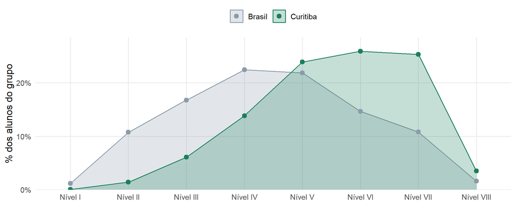

Os alunos de Curitiba têm perfil socioeconômico mais alto: 54,7% estão nos níveis VI a VIII do INSE, contra 27,1% no Brasil, e quase não há alunos da cidade nos níveis I e II. Como o INSE é o fator de gradiente mais claro, essa diferença precisa ser considerada na comparação.

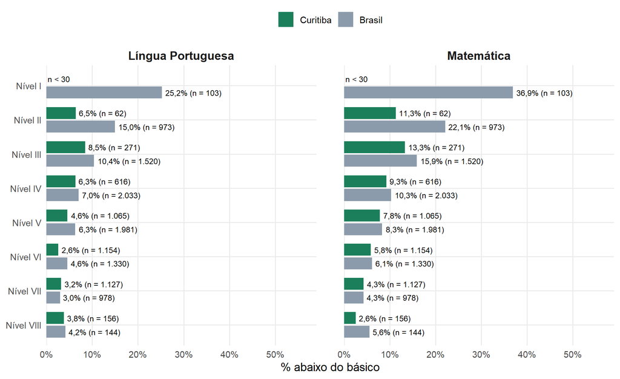

Comparando alunos de mesmo nível do INSE, a diferença entre Curitiba e Brasil diminui bastante, e em Matemática praticamente desaparece nos níveis IV a VII, onde estão quase 90% dos alunos de Curitiba. Para resumir esse efeito, calculamos a proporção que o Brasil teria se seus alunos estivessem distribuídos pelos níveis do INSE como os de Curitiba (padronização direta). Nesse caso, a proporção abaixo do básico do Brasil seria de 5,4% em LP e 7,6% em MT, contra os 7,7% e 11,0% observados. Curitiba tem 4,2% e 6,8%. A diferença em LP cai de 3,4 para 1,2 pontos percentuais, e a de MT, de 4,3 para 0,8. A maior parte da vantagem de Curitiba está associada ao perfil socioeconômico de seus alunos.

# 8 Conclusões

A hipótese do trabalho se confirma em parte. Várias características estão associadas a estar abaixo do nível básico, mas com intensidades diferentes.

A trajetória escolar é o bloco mais associado. Reprovação, idade acima da esperada para a série e abandono concentram as maiores proporções de alunos abaixo do básico e são características fáceis de observar pela escola. O nível socioeconômico vem em seguida, com o INSE mostrando o gradiente mais claro da análise, e boa parte das variáveis de família, bens e entorno repete esse resultado. Na rotina, trabalhar fora de casa e não ter tempo de lazer estão associados a proporções duas a três vezes maiores. Na relação com a escola, os alunos que não se sentem apoiados pelos professores têm proporções muito altas, embora sejam poucos. Os alunos que declaram deficiência ou transtorno do espectro autista têm mais que o dobro da proporção abaixo do básico.

Em Curitiba, a proporção abaixo do básico é menor que a do Brasil, mas a maior parte dessa vantagem acompanha o perfil socioeconômico mais alto dos alunos da cidade, e ela não aparece entre os filhos de mães com baixa escolaridade. Nos dois casos, Matemática é o ponto mais frágil.

Para a SME, boa parte dos alunos em risco pode ser identificada com informações que a escola já tem ou consegue obter, como histórico de reprovação e abandono, idade em relação à série e sinais de rotina sobrecarregada ou de afastamento em relação aos professores.

Esses resultados não provam causa. Eles mostram quais grupos concentram mais alunos abaixo do básico e quais variáveis devem ser levadas para a regressão logística, onde será possível verificar o que permanece quando as características são consideradas em conjunto.

# 9 Limitações

As proporções deste relatório subestimam a parcela real de alunos abaixo do básico, porque a base só inclui quem respondeu a todo o questionário, e os alunos excluídos têm desempenho pior. Pela mesma razão, grupos com mais dificuldade de leitura estão sub-representados.

Todas as características vêm das respostas de crianças de cerca de 10 anos, e parte delas não sabe responder ou não compreende algumas perguntas, como mostra o fato de quase metade não saber a escolaridade da mãe.

As associações foram medidas uma variável por vez. Como muitas variáveis andam junto com o nível socioeconômico, não é possível, nesta etapa, dizer qual delas tem efeito próprio.

Os intervalos de confiança supõem alunos sorteados de forma independente. Na amostra Brasil isso é razoável, pois os 9.062 alunos vêm de 7.783 escolas diferentes. Em Curitiba, os 4.452 alunos estão agrupados em 190 escolas, e alunos da mesma escola tendem a se parecer, de modo que os intervalos da cidade devem ser um pouco mais largos do que os calculados aqui.

Por fim, os cortes que definem “abaixo do básico” são os propostos pelo professor, e a base de Curitiba não distingue escolas municipais de estaduais, o que limita as conclusões específicas para a rede da SME.